# 21st Century Geographical Methods for Timeless Spatial Inequality Challenges

Rachel Franklin (@rsfrankl)

Newcastle University | The Alan Turing Institute

2024-10-27

A Tale Told in Three Chapters

Can also be played as interactive spot-the-geographical method bingo except no bingo cards.

# Acknowledgements

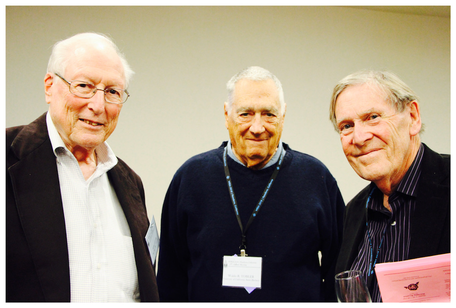

Art Getis, Waldo Tobler, and Bill Clark

# Prologue

What is *spatial inequality*?

The **observation of uneven attributes or outcomes over space**, for sure. But also the *processes* and *structures* producing that unevenness, as well as the *impacts* of those inequalities.

# Chapter 1

Spatial inequality and the smart city

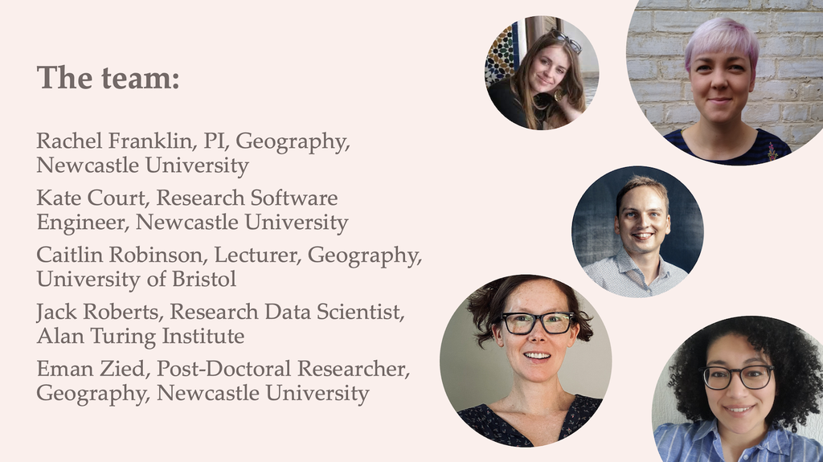

Thinking about how **emerging technologies** intersect with the **spatial demography of cities** to exacerbate, reproduce, and generate inequalities across areas or groups.

## Especially placement of sensors in the urban landscape

- Sensor coverage and “sensor deserts”
- Who’s in the “gaps”
- Equitable decision-making

## Why should we care about sensors and sensor networks?

## 1. They’re everywhere

[figure not shown]

## 2. Increasingly they’re essential urban infrastructure

- Policy decisions are made from sensor measurements
- Sensors and sensor networks help cities run

## 3. We humans are funny about infrastructure and equity

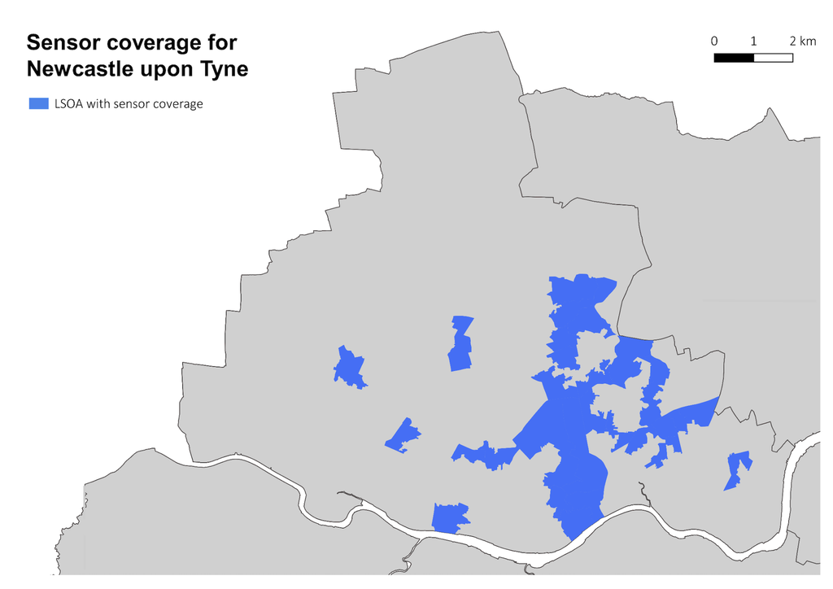

## 4. Even with good intentions we miss people and places

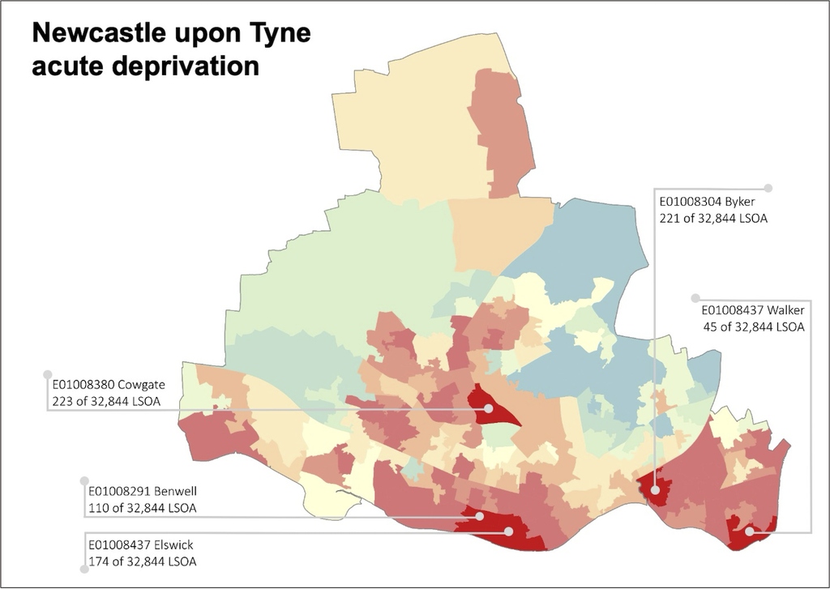

## The big idea

How can we support informed and equitable decision-making around sensor placement, especially what criteria *ideal* networks might satisfy and the inevitable trade-offs involved?

## Geographers have methods for this! (yay us!)

- What is the ”best” allocation of *n* sensors, given a particular goal?
  - **Single objective greedy algorithm**: Place sensors one by one and maximize coverage of one sub-group only.
  - **Multi-objective genetic algorithm (NSGA2)**: Generate a spectrum of networks representing the coverage trade-offs between different sub-groups.
- Decision support tools that visualize options and trade-offs

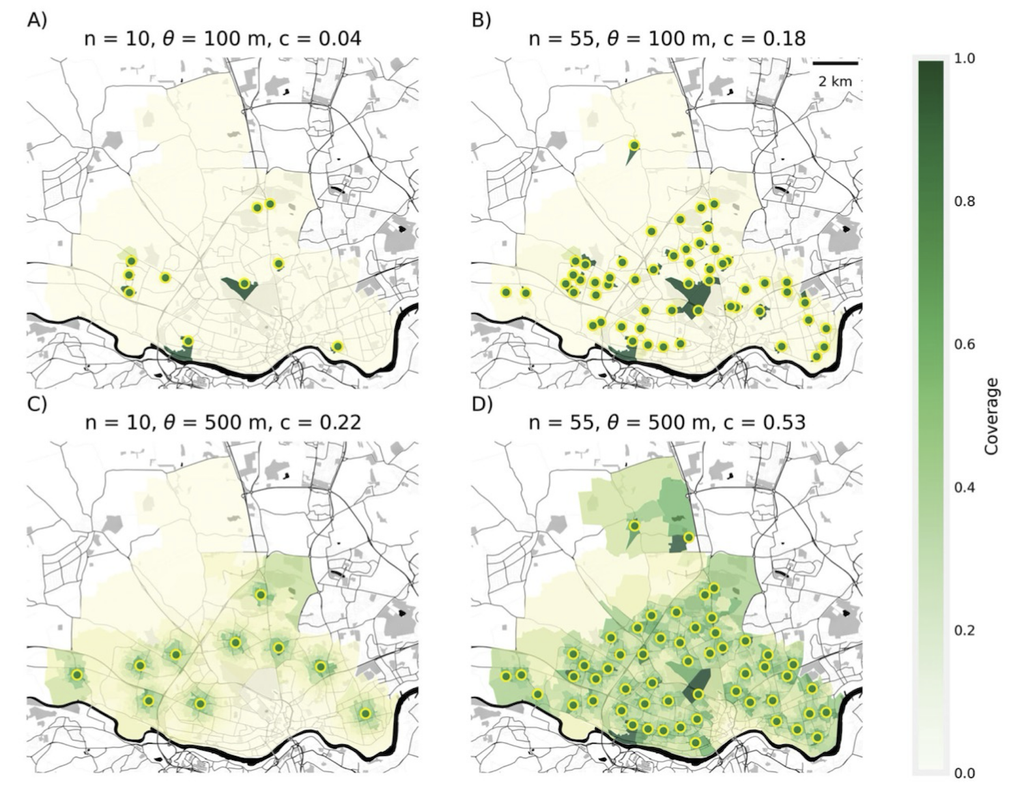

Coverage for older residents (>65)

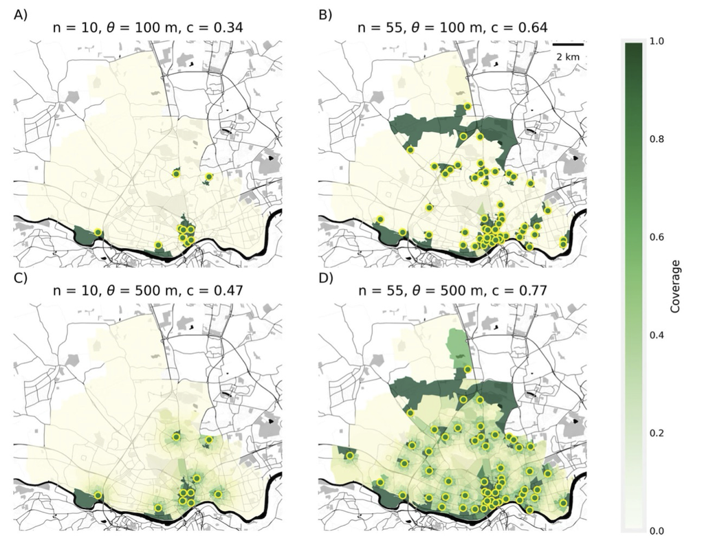

Coverage for place-of-work population

## Making it more user-friendly

[figure not shown]

## No fancy data here and well-known methods

But should make us think:

1. how are our data produced?
2. how can we do better?

# Chapter 2

Public transportation heat exposure in a warming world

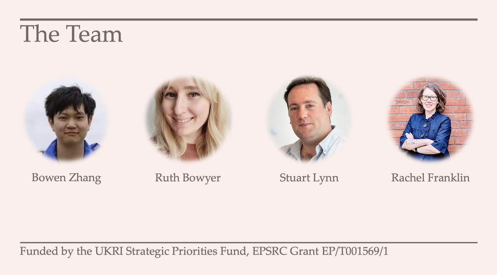

Thinking about the ways in which **health**, **climate change**, and **transportation** intersect

## Case in point: The London Tube

- The first Tube line opened in 1863 and is still running as part of the Metropolitan line
- 272 stations
- 11 lines, covering 402 kilometres
- More than five million passengers on the busiest days

## Future heat on the London Tube

- Only 4 out of 11 London underground lines have air conditioning systems
- The average summer temperature in London is expected to increase by 2.7 degrees Celsius by the 2050s
- The probability of heatwaves could also increase five-fold and they’re expected to occur every other year
- By 2070, the mean maximum air temperature in the UK in August is projected to increase by up to 6 °C in summer compared to 2018

## Hot is already here: Average station temperatures in London (2019)

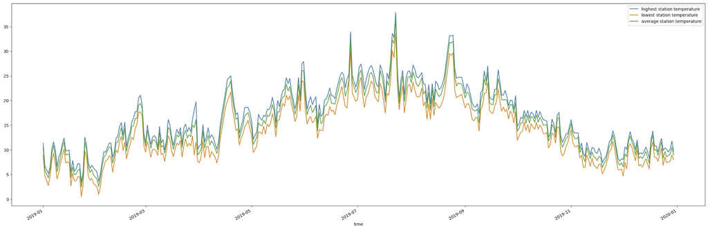

## The big idea

How can we estimate current and future heat exposure on the Tube *and* who (where) is most affected?

## Simple (and important) question with complex data requirements

- Travel flows (origins and destinations)
- Who’s travelling? (demographic and health characteristics)
- What’s the temperature on board? (estimated from known station-surface differentials)

## Exciting geographical tools

- **Synthetic Population Catalyst** (SPC)–A synthetic population that simulates individual-level travel behaviour (homeplace and workplace), travel mode, person and socio-economic factors that allow us to explore heat vulnerability at the individual level
- **Tube operation timetable**–For travel times and route estimation, we use the timetable provided by TfL APIs. Provides accurate estimation whether travellers for each OD-pair will take air-conditioned Tube lines.
- **Clim-recal**–Estimates weather and heat wave days in the past *and* future on a daily basis in 2.2 km*2.2 km cells covering the entire UK. Local variation in the dataset is used to estimate heat exposure more accurately.

## Preliminary results (a sense of where we’re heading)

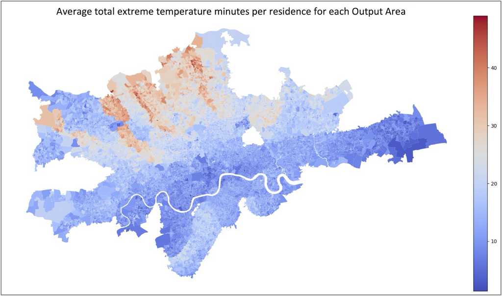

- The inequality of heat exposure risk is significant in spatial terms
- Trickiness of estimation but lots of useful **data** that can be brought to bear
- **But** also some of this should be being measured directly!

# Chapter 3

Making satellite imagery data *usable*, *useful*, and *used* in the social sciences and health

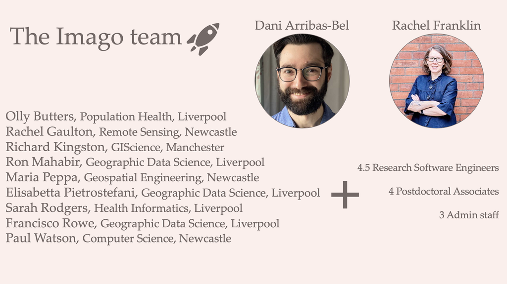

Thinking about how many decades<sup>1</sup> we’ve been talking about the potential for **satellite imagery** to be a **social science data** game-changer.

[^1]: two? three?

## What’s stopping us?

- Lack of useful data products
- Skills and capacity
- Data products in formats (and locations) social scientists and health folks are used to
- Interfaces that serve data that people want to use
- Until pretty recently: high-resolution imagery, plus the tools to ingest, extract, and package at scale

## The big idea

We’ve now got the compute, methods, and sensor quality for satellite imagery to be a game-changer for social science and health research and policy making

## Introducing the ESRC SDR Imagery Data Service*

**1. Imagery innovation**–research-ready imagery-based data products, building off and developing innovative computing and AI methods that facilitate efficient automated workflows for measures and indicators, as well as custom-defined geographies and time periods.

**2. Data for all**–data distribution channels that meet researchers and policymakers where they are, with user-friendly interfaces, familiar file formats, linkage and integration with existing data resources

**3. Capability and community**–building capacity for understanding and working with imagery and imagery-derived data, growing the user-base and providing thought leadership, and heightening awareness and enthusiasm for the value of imagery

*Code name: Imago

# Epilogue

## Complex spatial inequality challenges require complex approaches<sup>1</sup>

- Inter-disciplinarity
- Geography
- A lot of social science under the hood <sup>2</sup>
[^2]: not necessarily complex methods
[^3]: starting with a question, building with theory, and then selecting the most appropriate methods

## The question chooses the method.

(Not the other way around)

## Last takeaways

(through the lens of yesterday’s conversation)

- We really mustn’t forget to talk about data
- Basic principles of good estimators (i.e., methods): consistent, unbiased, efficient
- How does GeoAI (however we are defining it) fit into the broader suite of existing geographical methods? Do we draw boundaries? Build walls? Moats?
- I’d love to see us all talking to each other more

# The End.

Thank you!!